# Estruturas de Dados e Algoritmos

## Fase 2 - Visualização do conteúdo dos ficheiros Excel disponibilizados

Primeiro, começamos por analisar o conteúdo dos ficheiros Excel, uma vez que não sabíamos o que estes tinham no seu interior. Decidimos explorar em primeiro lugar o ficheiro "Github1" e para isso escrevemos o código em baixo:

```python
import csv
lista_profile = []  # lista relativa ao ficheiro "Github1.csv"
profile = open("Github1.csv")  # abrir ficheiro
read_profile_excel = csv.reader(profile)  # ler ficheiro

for p in profile:
    lista_profile.append(p)  # para acrescentar elemento p à lista_profile
lista_profile.pop(0)  # retirar a primeira linha do Excel com a denominação follower, followed, para só termos os
# conteúdos que realmente interessam

print(lista_profile)
```

De seguida, realizamos o mesmo processo para o ficheiro "Data_Facebook".

```python
import csv
lista_data = []  # lista relativa ao ficheiro "Data_Facebook.csv"
data_excel = open("Data_Facebook.csv")  # abrir ficheiro
read_data_excel = csv.reader(data_excel)  # ler ficheiro

for i in read_data_excel:
    lista_data.append(i)  # acresenta todos os elementos à lista, incluindo os da primeira linha, porque não há "títulos"

print(lista_data)
```

Deste modo, críamos uma lista vazia chamada lista_data. De seguida, abrimos e lemos o ficheiro Excel "Data_Facebook" com recurso ao pacote csv e este vai acrescentar o seu conteúdo elemento a elemento na lista_data. Neste caso, como este não tem cabeçalhos são adicionados elementos logo desde a primeira linha. Assim, observamos que este ficheiro é constituído por 3 colunas que contém o nome de duas pessoas diferentes e um número, todos separados por vírgulas.

Realizamos um processo semelhante para o ficheiro "facebook_network".

```python
import csv
lista_circle = []  # lista relativa ao ficheiro "facebook_network.csv"
network_excel = open("facebook_network.csv")  # abrir ficheiro Excel
read_network_excel = csv.reader(network_excel)  # ler ficheiro Excel

for n in read_network_excel:
    lista_circle.append(n)  # acresenta todos os elementos à lista, incluindo os da primeira linha, porque não há "títulos"

print(lista_circle)
```

## Fase 3 - Visualização do grafo

Como já sabíamos o conteúdo dos ficheiros, começamos a pensar numa estratégia para desenhar o grafo com informação relativa aos ficheiros csv. Para isso criamos duas funções - grafo_csv e nx_teste. A primeira está relacionada com o ficheiro Excel e com os elementos deste, percorrendo-o e adicionando-os no grafo. A segunda prende-se com o desenho do grafo, utilizando os pacotes networkx e mathplotlib.pyplot. Vamos começar por ver a função grafo_csv.

Para termos a certeza de que as nossas funções estavam a funcionar decidimos criar um ficheiro Excel chamado teste, com apenas 7 linhas, o que nos permitiu visualizar em concreto o que estava a acontecer. De seguida, testamos com o ficheiro "facebook_network". Desta forma, pudemos dar esta parte por concluída e seguir para as outras etapas do projeto.

##### Função grafo_csv

A função grafo_csv(nome_f) permite-nos abrir, ler, percorrer o ficheiro Excel e inserir os vértices e arestas no grafo.

```python
import csv

# grafo e ficheiro excel, percorrendo-o
def grafo_csv(nome_f):
    grafo = Graph()  # obter a classe Grafo, já que está definido que o grafo é não direcionado
    data_excel = open(nome_f)  # abrir o ficheiro
    read_data_excel = csv.reader(data_excel)  # ler o ficheiro
    s = set()  # cria um conjunto vazio
    for item in read_data_excel:  # ciclo for
        pessoa_1 = item[0]  # ponto de partida da aresta
        pessoa_2 = item[1]  # ponto de chegada da aresta
        if (pessoa_1, pessoa_2) not in s and (pessoa_2, pessoa_1) not in s:  # se ainda não está no set
            amizade = item[2]  # peso da aresta
            grafo.insert_edge(grafo.insert_vertex(pessoa_1), grafo.insert_vertex(pessoa_2), int(amizade))  # insere no grafo
            s.add((pessoa_1, pessoa_2))  # adiciona no set
    data_excel.close()  # fechar o ficheiro Excel
    return grafo  # devolve o grafo com a informação anterior
```

Esta função começa por chamar a classe Graph e por abrir e extrair o ficheiro Excel, utilizando o módulo csv. De seguida, lê-o e separa os conteúdos que no ficheiro Excel estão entre vírgulas. Críamos um ciclo que itera todo o conteúdo do ficheiro, percorrendo-o e atribuindo os valores da coluna 1 a pessoa_1, da coluna 2 a pessoa_2 e da coluna 3 a amizade.

Vai inserir o vértice pessoa_1 no grafo, através do método insert_vertex da classe Graph, sendo que o mesmo se verifica para pessoa_2.

Por fim, com o método_insert_edge da classe Graph insere uma aresta, que contém o vértice pessoa_1, o vértice pessoa2 e o peso amizade.

É importante notar que o ficheiro Excel que nos foi dado tinha entradas repetidas, o que inicialmente foi um problema, quando tentamos mais tarde implementar o Kruskal e o clustering, pois o nosso grafo é não direcionado. Dado este problema, fomos à procura de soluções e depois de várias tentativas, decidimos não somar o peso das arestas repetidas, mas sim apenas considerar o peso da primeira linha que aparecesse com arestas iguais. Deste modo, críamos um conjunto vazio, e vemos se a aresta que liga pessoa_1 e pessoa_2 ou a aresta que liga pessoa_2 e pessoa_1 já estão no conjunto, se não estiver é adicionada. Isto permitiu-nos adicionar apenas 7235 arestas em vez das 10000 inicialmente no ficheiro.

##### Função nx_teste

```python
import networkx as nx
import mathplotlib.pyplot as plt

# desenhar o grafo com recurso ao networkx e mathplotlib.pyplot
def nx_teste(graf, show_plot=False):
    nx_g = nx.Graph()  # vai desenhar o grafo do Tad_grafo.py com o recurso ao networkx
    for i in graf.edges():  # se i está nas arestas do grafo
        #print(i)
        # print(i._pessoa_1)
        # print(i._pessoa_2)
        nx_g.add_edge(i._pessoa_1._pessoa, i._pessoa_2._pessoa,
                          weight=i._amizade)  # adiciona ao desenho uma aresta com
        # o vérice pessoa_1, o vértice pessoa_2 e com peso amizade
        print(i._pessoa_1, "->", i._pessoa_2, "=", i._amizade)
    # desenhar
    if show_plot:
        desenho = nx.spring_layout(nx_g)  # desenho das posições dos nós de acordo com a disposição spring_layout
        nx.draw_networkx_nodes(nx_g, desenho, node_size=400,
                                   node_color="#32CD32", edgecolors="#8DEEEE")  # desenha apenas os nós do grafo,
        # com tamanho e cor definido por nós
        nx.draw_networkx_labels(nx_g, desenho, font_size=7)  # põe a legenda nos nós grafo, o tamnaho da letra é 7
        nx.draw_networkx_edges(nx_g, desenho, width=3)  # desenha as arestas do grafo, com largura igual a 3
        nx.draw_networkx_edge_labels(nx_g, desenho, font_size=6)  # põe a legenda nas arestas, neste caso o peso
        plt.axis("off")  # remover os eixos do x e y do desenho
        plt.show()  # para mostrar o grafo
```

Esta função permite desenhar o grafo com recurso ao networkx e mathplotlib.pyplot. Começa por chamar o módulo networkx e a classe Graph. Cria um ciclo para acrescentar com o método add_edge do networkx, uma aresta i constituída pelo vértice pessoa_1 e pelo vértice pessoa_2 com um peso de amizade. Quanto ao desenho em si, não vão ser mostrados os eixos do x, nem do y. Os nós dos grafos vão ser dispostos da forma spring_layout e o desenho vai ter o nome das pessoas dentro de nós verdes com rebordo azul e arestas com o peso.

Decidimos testar este código em primeiro lugar no ficheiro de teste e obtivemos o seguinte resultado:

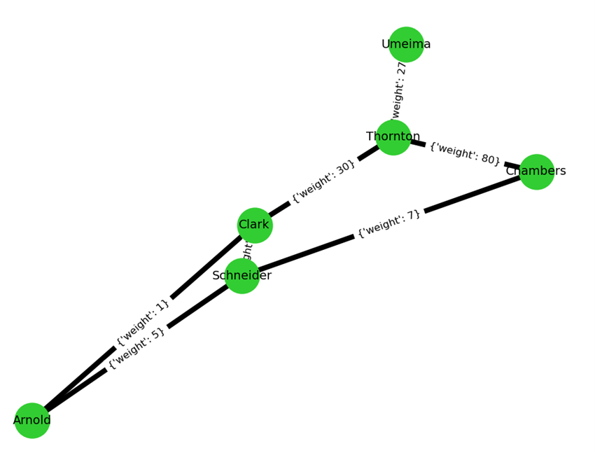

De seguida, ao verificarmos que tínhamos obtido o resultado certo no ficheiro de teste decidimos implementar o código no ficheiro Excel "facebook_network".

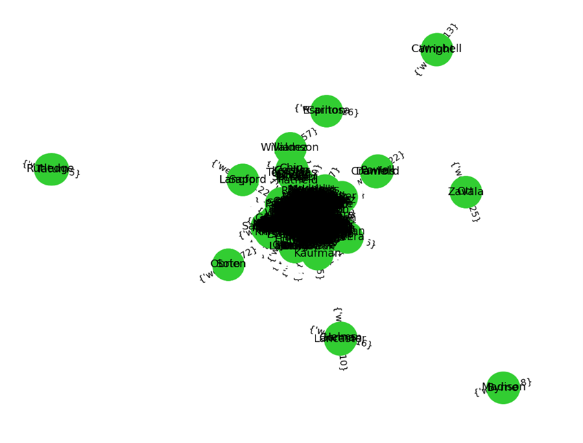

Devido à difícil compreensão decidimos diminuir o tamanho dos nós para 20 e retirar qualquer tipo de legenda. Deste modo o código utilizado e o resultado obtidos foram os seguintes:

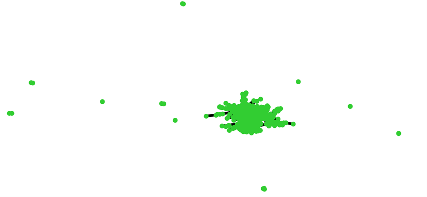

```python
def nx_teste(graf, show_plot=False):
    nx_g = nx.Graph()  # vai desenhar o grafo do Tad_grafo.py com o recurso ao networkx
    for i in graf.edges():  # se i está nas arestas do grafo
        #print(i)
        # print(i._pessoa_1)
        # print(i._pessoa_2)
        nx_g.add_edge(i._pessoa_1._pessoa, i._pessoa_2._pessoa,
                          weight=i._amizade)  # adiciona ao desenho uma aresta com
        # o vérice pessoa_1, o vértice pessoa_2 e com peso amizade
        print(i._pessoa_1, "->", i._pessoa_2, "=", i._amizade)
    # desenhar
    if show_plot:
        desenho = nx.spring_layout(nx_g)  # desenho das posições dos nós de acordo com a disposição spring_layout
        nx.draw_networkx_nodes(nx_g, desenho, node_size=20,
                                   node_color="#32CD32", edgecolors="#8DEEEE")  # desenha apenas os nós do grafo,
        # com tamanho e cor definido por nós
        nx.draw_networkx_edges(nx_g, desenho, width=3)  # desenha as arestas do grafo, com largura igual a 3
        plt.axis("off")  # remover os eixos do x e y do desenho
        plt.show()  # para mostrar o grafo
```

## Fase 4 - Algoritmo de Kruskal e árvores de cobertura mínima

O algoritmo de Kruskal é uma forma de implementar árvores de cobertura mínima, logo é importante sabermos o que estas são.

As árvores de cobertura mínima são árvores em que todos os vértices estão conectados, não há ciclos, o peso total da árvore é o menor possível, as arestas são um subconjunto das arestas do grafo.

O algoritmo de Kruskal é uma implementação possível das árvores de cobertura mínima. Este começa por ordenar as arestas da com menor para a com maior peso. De seguida, pega na aresta com menor peso e adiciona-a à árvore de cobertura. Como o algoritmo privilegia a aresta de custo mínimo, se a aresta criar um ciclo ela é rejeitada. Este processo é continuado até que as arestas adicionadas cheguem a todos os vértices, até que a árvore de cobertura mínima seja criada, tal como se pode ver na imagem em baixo.

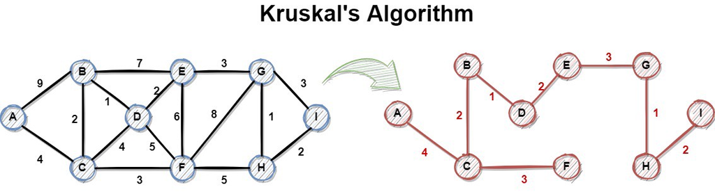

Este algoritmo é do tipo union-find, daí que tenhamos criado os métodos make_set(pessoa), find(pessoa), union(pessoa_1, pessoa_2).

Decidimos implementar o método make_set(pessoa) da seguinte forma:

```python
 def make_set(self, pessoa):
        self._pai[pessoa] = pessoa              # pai do vértice
        self._rank[pessoa] = 0                  # rank do vértice
```

O método make_set(pessoa) cria um novo conjunto ao criar um novo elemento com um identificador único, um rank de 0 e um ponteiro pai para ele mesmo, o que indica que o elemento representa o seu próprio conjunto. Tem complexidade temporal de O(1).

Decidimos implementar o método find(pessoa) da seguinte forma:

```python
def find(self, pessoa):
    if self._pai[pessoa] != pessoa:
        self._pai[pessoa] = self.find(self._pai[pessoa])
    return self._pai[pessoa]
    # encontrar o pai do vértice
```

O método find(pessoa) segue a cadeia de ponteiros pai da árvore a partir de pessoa até ao elemento, cujo pai é ele próprio. Este elemento é a raiz da árvore e é um membro representativo do conjunto, ao qual pessoa pertence e pode ser o próprio elemento pessoa.

Decidimos implementar o método union(pessoa_1, pessoa_2) da seguinte forma:

```python
def union(self, pessoa_1, pessoa_2):                 # ligar pessoa_1 e pessoa_2 ao mesmo pai
    raiz_1 = self.find(self._pai[pessoa_1])
    raiz_2 = self.find(self._pai[pessoa_2])

    if raiz_1 != raiz_2:                             # diferentes pais dos vértices
        if self._rank[raiz_1] > self._rank[raiz_2]:
            self._pai[raiz_2] = raiz_1
        else:
            self._pai[raiz_1] = raiz_2
    if self._rank[raiz_1] == self._rank[raiz_2]:
        self._rank[raiz_2] += 1
```

O método union(pessoa_1, pessoa_2) utiliza o método find(pessoa) para determinar as raízes das árvores a que pessoa_1 e pessoa_2 pertencem. Se as raízes forem diferentes, as árvores vão ser combinadas ao anexar as duas raízes distintas, uma à outra.

Decidimos implementar o método kruskal(), que junta os métodos make_set(pessoa), find(pessoa) e union(pessoa_1, pessoa_2) da seguinte forma:

```python
def kruskal(self):                                             # para ter a árvore de cobertura mínima
    minimum_spanning_tree = Graph()
    self.graph = sorted(self.graph, key=lambda item: item[2])  # ordenar toodas as arestas por peso

    for node in self._vertices:
        self.make_set(node.__str__())                          # definir o valor inicial do pai e rank

    for edge in self.graph:
        pessoa_1, pessoa_2, amizade = edge
        x = self.find(pessoa_1.__str__())
        y = self.find(pessoa_2.__str__())                      # para ter os pais dos 2 vértices x, y
        if x != y:                                             # se os 2 nós estão no mesmo grupo de conexão
            minimum_spanning_tree.insert_edge(minimum_spanning_tree.insert_vertex(pessoa_1._pessoa), minimum_spanning_tree.insert_vertex(pessoa_2._pessoa), amizade)
            self.union(x, y)                                   # ligar os 2 nós
    return minimum_spanning_tree
```

É importante salientar que ao início tivemos alguns problemas no método kruskal(), porque não estávamos a conseguir ligar os nós da árvore de cobertura mínima, no entanto, depois de muitas tentativas percebemos que tínhamos que acrescentar ._pessoa depois de insert_vertex.

```python
def print(self):                                               # imprimir aresta com peso
    t_amizade = 0                                              # peso do grafo
    for edge in self.graph:
        pessoa_1, pessoa_2, amizade = edge
        t_amizade += amizade
```

Para mostrar o grafo segundo a forma de árvore de cobertura mínima utilizamos a função grafo_csv, tal como explicamos em cima, e a função nx_teste_kruskal, explicada em seguida.

```python
import csv
import mathplotlib.pyplot as plt

# desenhar o grafo aplicando o kruskal usando o networkx e mathplotlib.pyplot
def nx_teste_kruskal(graf, show_plot=False):
    nx_g = nx.Graph()  # desenha o grafo da Tad_grafo.py utilizando networkx
    graph_amizade = 0  # peso do grafo
    for i in graf.edges():  # se i está nas arestas do grafo
        graph_amizade += i._amizade
        nx_g.add_edge(i._pessoa_1._pessoa, i._pessoa_2._pessoa, weight=i._amizade)  # adiciona um aresta ao desenho
        print(i._pessoa_1, "->", i._pessoa_2, "=", i._amizade)  # adiciona uma aresta ao desenho
    print("*****************************")
    print("O peso da árvore geradora mínima é: ", graph_amizade)

    # o vértice pessoa_1, o vértice pessoa_2 e o peso amizade
    if show_plot:
        desenho = nx.spring_layout(nx_g)  # desenho das posições dos nós de acordo com a disposição spring_layout
        nx.draw_networkx_nodes(nx_g, desenho,
                               node_size=400,
                               node_color="#32CD32", edgecolors="#8DEEEE")  # desenha apenas os nós do grafo,
        # com tamanho e cor definido por nós
        nx.draw_networkx_labels(nx_g, desenho,
                                font_size=7)  # põe a legenda nos nós grafo, o tamnaho da letra é 7
        nx.draw_networkx_edges(nx_g, desenho, width=3)  # desenha as arestas do grafo, com largura igual a 3
        nx.draw_networkx_edge_labels(nx_g, desenho,
                                     font_size=6)  # põe a legenda nas arestas, neste caso o peso
        plt.axis("off")  # remover os eixos do x e y do desenho
        plt.show()  # para mostrar o grafo
```

Para verificar que tudo estava bem decidimos testar este código em primeiro lugar no ficheiro de teste e obtivemos o seguinte resultado:

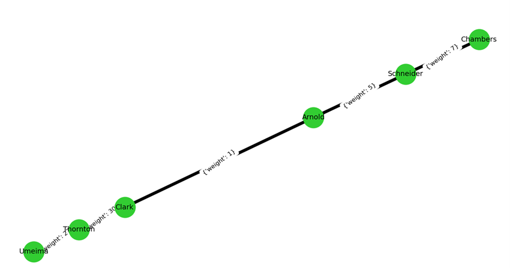

De seguida, ao obtermos um resultado satisfatório no ficheiro de teste decidimos implementar o código no ficheiro Excel "facebook_network".

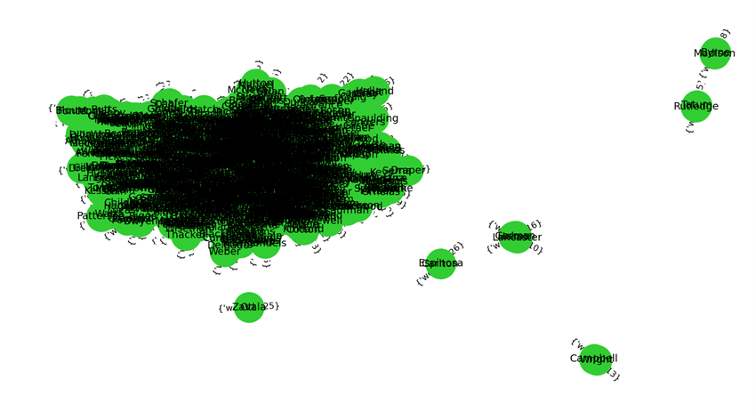

Devido à difícil compreensão decidimos diminuir o tamanho dos nós para 20 e retirar qualquer tipo de legenda. Deste modo o código utilizado e o resultado obtido foram os seguintes:

[figure not shown]

```python
def nx_teste_kruskal(graf, show_plot=False):
    nx_g = nx.Graph()  # desenha o grafo da Tad_grafo.py utilizando networkx
    graph_amizade = 0  # peso do grafo
    for i in graf.edges():  # se i está nas arestas do grafo
        graph_amizade += i._amizade
        nx_g.add_edge(i._pessoa_1._pessoa, i._pessoa_2._pessoa, weight=i._amizade)  # adiciona um aresta ao desenho
        print(i._pessoa_1, "->", i._pessoa_2, "=", i._amizade)  # adiciona uma aresta ao desenho
    print("*****************************")
    print("O peso da árvore geradora mínima é: ", graph_amizade)

    # o vértice pessoa_1, o vértice pessoa_2 e o peso amizade
    if show_plot:
        desenho = nx.spring_layout(nx_g)  # desenho das posições dos nós de acordo com a disposição spring_layout
        nx.draw_networkx_nodes(nx_g, desenho,
                               node_size=20,
                               node_color="#32CD32", edgecolors="#8DEEEE")  # desenha apenas os nós do grafo,
        # com tamanho e cor definido por nós
        plt.axis("off")  # remover os eixos do x e y do desenho
        plt.show()  # para mostrar o grafo
```

## Fase 5 - Clustering com recurso ao single-linkage e comunidades

O clustering é um método de aprendizagem não supervisionado e consiste na análise de agrupamento de dados e é um conjunto de técnicas que pretende fazer agrupamentos de dados consoante o seu grau de semelhança. Deste modo, dados semelhantes ficam agrupados no mesmo grupo e distantes dos dados com características diferentes.

O clustering hierárquico começa com o tratamento de cada observação como um cluster individual e, em seguida, junta os clusters iterativamente até que todos os pontos de dados sejam aglomerados num único cluster. Os clusters são aglomerados com base na distância entre eles e para calcular a distância entre os clusters temos diferentes tipos de ligações (linkages).

Na imagem em baixo, podemos ver as diferentes formas de linkage que existem. Para este trabalho em específico e considerando as suas especificidades decidimos implementar o algoritmo de single-linkage que é um exemplo de um método de clustering hierárquico do tipo aglomerativo, ou seja, a estratégia é do tipo bottom-up, pelo que comparamos cada ponto de baixo para cima. Cada objeto é posto num cluster separado e em cada passo fundimos o par mais perto dos clusters, até que certas condições fiquem satisfeitas.

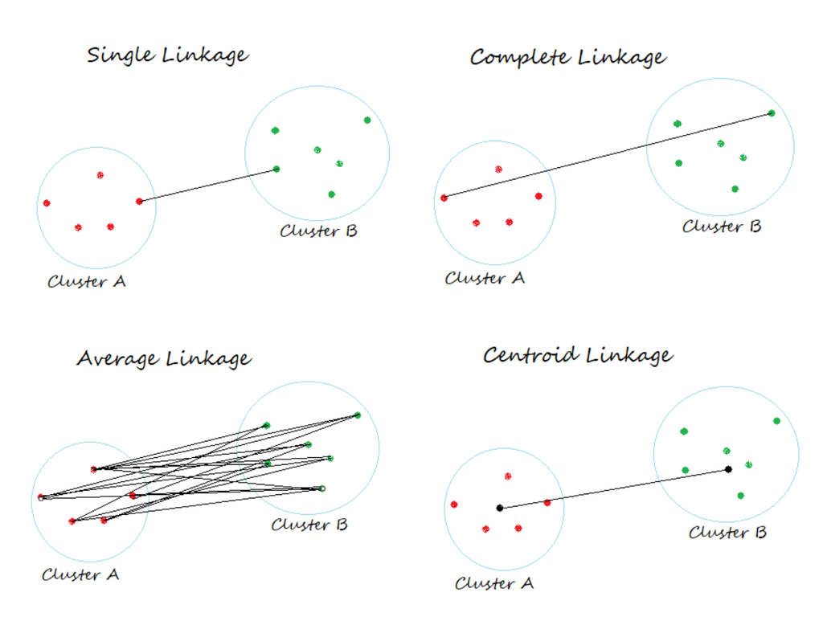

Para implementarmos a função clusters, com o objetivo de aplicarmos o clustering single-linkage com o algoritmo de Kruskal, utilizamos o pseudocódigo disponibilizado nos PowerPoints, tal como se pode observar em baixo. Note-se que o número de clusters (k) será dado como atributo ao ser chamada a função clusters.

```python
import csv
import mathplotlib.pyplot as plt

# desenhar o grafo aplicando o clustering e o kruskal usando o networkx e mathplotlib.pyplot
def clusters(graph, k=2, show_plot=False):
    n_clusters = k
    print('Número de arestas únicas:',desenhar.edge_count())  # fixo
    nx_g = nx.Graph() # vai desenhar o grafo do Tad_grafo.py com o recurso ao networkx
    max = Edge(0, 0, 0) # cria um objeto da classe Edge com as pessoas e a amizade em 0
    graph_w_kruskal = graph.kruskal() # vai aplicar o algoritmo de kruskal ao grafo que foi construído a partir dos dados
    # do ficheiro
    if k<=1:
        raise ValueError('O número de clusters só pode tomar valores naturais, superiores a 1.')
    while k - 1 != 0: # ciclo para percorrer as partições dos clusters (k-1 partições; k=nª de clusters)
        for i in graph_w_kruskal.edges(): # percorrer as arestas do grafo com o kruskal implementado
            if i._amizade > max.amizade(): # comparar o número da amizade a procurar com o valor do *max*
                max = i # caso for maior que a amizado do *max* vai substituir o valor da amizade no *max*
        print('Retirar:',(max), max.amizade()) # dar print do elemento maior dps de percorrer o grafo todo
        graph_w_kruskal.remove_edge(max._pessoa_1, max._pessoa_2) # remove a aresta com maior peso
        max = Edge(0, 0, 0) # reset do *max*, objeto da classe Edge (apenas para a continuação do ciclo)
        k -= 1 # diminuição do k para a continuação do ciclo
    print('\n')
    for j in graph_w_kruskal.edges():  # se i está nas arestas do grafo
        nx_g.add_edge(j._pessoa_1._pessoa, j._pessoa_2._pessoa, weight=j._amizade)  # adiciona ao desenho uma aresta com
        # o vértice pessoa_1, o vértice pessoa_2 e com peso amizade
        #print(j._pessoa_1, "->", j._pessoa_2, "=", j._amizade)

    print('=====================================\nComunidades com o número de clusters:\n'
          '=====================================\n')
    k_cliques(nx_g,n_clusters)
    # se o k for maior ou igual a 3 ele irá apenas ver as comunidades, usando o louvain
    louvain(nx_g)

    if show_plot:
        desenho = nx.spring_layout(nx_g)  # desenho das posições dos nós de acordo com a disposição spring_layout
        nx.draw_networkx_nodes(nx_g, desenho, node_size=400,node_color="#32CD32", edgecolors="#8DEEEE")
        # desenha apenas os nós do grafo, com tamanho definido por nós
        nx.draw_networkx_labels(nx_g, desenho, font_size=7)  # põe a legenda nos nós grafo, o tamnaho da letra é 7
        nx.draw_networkx_edges(nx_g, desenho, width=3)  # desenha as arestas do grafo, com largura igual a 3
        nx.draw_networkx_edge_labels(nx_g, desenho, font_size=6)  # põe a legenda nas arestas, neste caso o peso
        plt.axis("off")  # remover os eixos do x e y do desenho
        plt.show()  # para mostrar o grafo
```

Esta função começa por chamar a classe Graph, desenvolvida em Tad_grafo.py. De seguida, cria um objeto da classe Edge com os vértices pessoa_1 e pessoa_2 a zero, tal como o peso da aresta, aqui representada por amizade. Críamos um ValueError para quendo o k é igual ou menor que 1, visto que não pode "partir" arestas, uma vez que se partem k - 1 arestas. Ao chamar o método kruskal(), este método vai ser aplicado ao grafo que foi contruído a partir dos dados dentro do ficheiro Excel. Críamos um ciclo while para percorrer as partições dos clusters (número de clusters - 1 partição), o for percorre as arestas do grafo, com o kruskal implementado e o if compara o número da amizade a procurar com o valor da variável max. Se o i do ciclo for for maior que o peso da aresta (amizade) da variável max , vai substituir o valor da amizade na variável max. Deste modo, vai remover a aresta com o maior peso e a variável max, vai voltar a zeros, apenas para que o ciclo possa continuar, tal como a diminuição de k em 1.

Esta função imprime o maior elemento do grafo depois de o percorrer, sendo este o elemento que se deve eliminar e imprime os vértices e o peso da aresta que vão ser desenhados.

Com o objetivo de estudarmos as comunidades presentes no nosso ficheiro implementamos as funções louvain e k_cliques.

Ao implementar este algoritmo tivemos algumas dificuldades, porque ao aplicarmos o clustering não conseguimos obter nós separados caso a aresta rompida seja a que liga a um vértice das extremidades. Ao início, também tivemos dificuldades na medida em que não conseguíamos obter nenhum desenho, uma vez que não apareciam nem vértices, nem arestas. Resolvemos este problema com o código em baixo:

```python
for j in graph_w_kruskal.edges():  # se i está nas arestas do grafo
        nx_g.add_edge(j._pessoa_1._pessoa, j._pessoa_2._pessoa, weight=j._amizade)
```

Decidimos testar este código em primeiro lugar no ficheiro de teste, com o objetivo de verificar que a nossa implementação estava a funcionar e obtivemos o seguinte resultado:

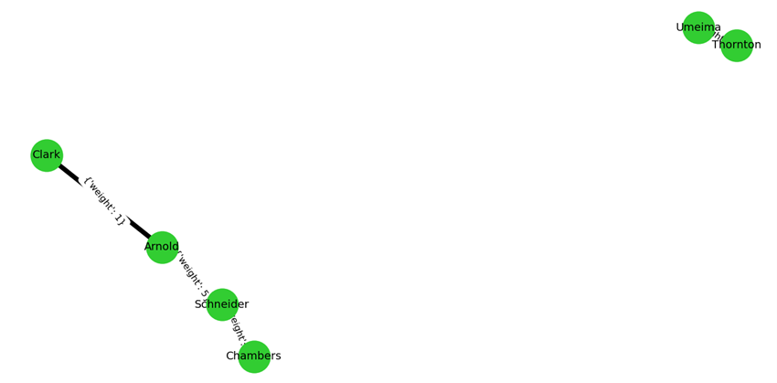

Nota: para a imagem em cima utilizamos k = 2, pois temos poucas linhas no ficheiro Excel de teste, logo não é necessário quebrar mais ligações porque o nosso grafo ficaria muito disperso.

De seguida, ao verificarmos que tínhamos obtido o resultado pretendido no ficheiro de teste decidimos implementar o código no ficheiro Excel "facebook_network", também com k = 2.

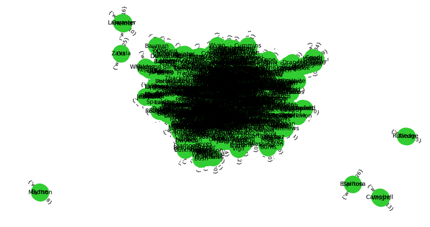

Devido à difícil compreensão do grafo com k = 2 decidimos diminuir o tamanho dos nós para 20 e retirar qualquer tipo de legenda, pelo que utilizamos o seguinte código.

```python
def clusters(graph, k=2, show_plot=False):
    n_clusters = k
    print('Número de arestas únicas:',desenhar.edge_count())  # fixo
    nx_g = nx.Graph() # vai desenhar o grafo do Tad_grafo.py com o recurso ao networkx
    max = Edge(0, 0, 0) # cria um objeto da classe Edge com as pessoas e a amizade em 0
    graph_w_kruskal = graph.kruskal() # vai aplicar o algoritmo de kruskal ao grafo que foi construído a partir dos dados
    # do ficheiro
    if k<=1:
        raise ValueError('O número de clusters só pode tomar valores naturais, superiores a 1.')
    while k - 1 != 0: # ciclo para percorrer as partições dos clusters (k-1 partições; k=nª de clusters)
        for i in graph_w_kruskal.edges(): # percorrer as arestas do grafo com o kruskal implementado
            if i._amizade > max.amizade(): # comparar o número da amizade a procurar com o valor do *max*
                max = i # caso for maior que a amizado do *max* vai substituir o valor da amizade no *max*
        print('Retirar:',(max), max.amizade()) # dar print do elemento maior dps de percorrer o grafo todo
        graph_w_kruskal.remove_edge(max._pessoa_1, max._pessoa_2) # remove a aresta com maior peso
        max = Edge(0, 0, 0) # reset do *max*, objeto da classe Edge (apenas para a continuação do ciclo)
        k -= 1 # diminuição do k para a continuação do ciclo
    print('\n')
    for j in graph_w_kruskal.edges():  # se i está nas arestas do grafo
        nx_g.add_edge(j._pessoa_1._pessoa, j._pessoa_2._pessoa, weight=j._amizade)  # adiciona ao desenho uma aresta com
        # o vértice pessoa_1, o vértice pessoa_2 e com peso amizade
        #print(j._pessoa_1, "->", j._pessoa_2, "=", j._amizade)

    print('=====================================\nComunidades com o número de clusters:\n'
          '=====================================\n')
    k_cliques(nx_g,n_clusters)
     # se o k for maior ou igual a 3 ele irá apenas ver as comunidades, usando o louvain
    louvain(nx_g)

    if show_plot:
        desenho = nx.spring_layout(nx_g)  # desenho das posições dos nós de acordo com a disposição spring_layout
        nx.draw_networkx_nodes(nx_g, desenho, node_size=20,node_color="#32CD32", edgecolors="#8DEEEE")
        # desenha apenas os nós do grafo, com tamanho definido por nós
        nx.draw_networkx_edges(nx_g, desenho, width=3)  # desenha as arestas do grafo, com largura igual a 3
        plt.axis("off")  # remover os eixos do x e y do desenho
        plt.show()  # para mostrar o grafo
```

Começamos por experimentar diferentes k, por exemplo k = 2, k = 3 e k = 4.

```
                                                K = 2
```

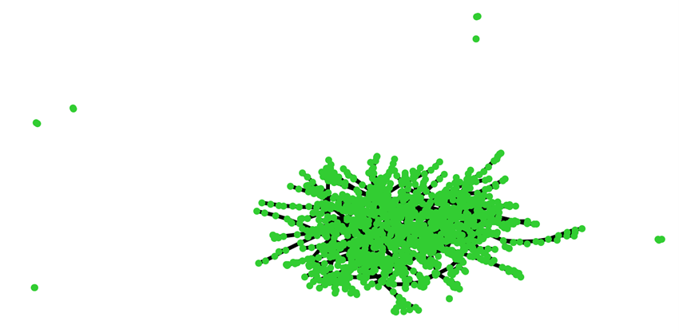

```
                                                    k = 3
```

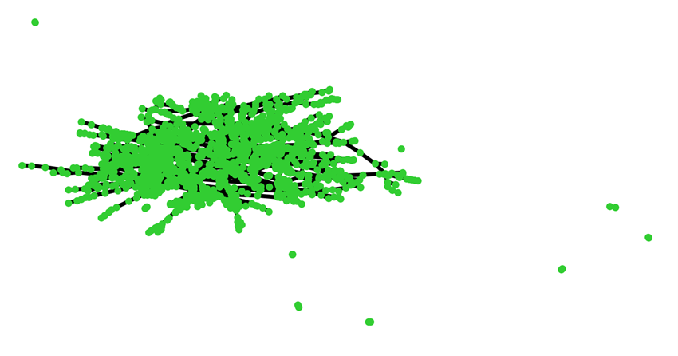

```
                                                        k = 4
```

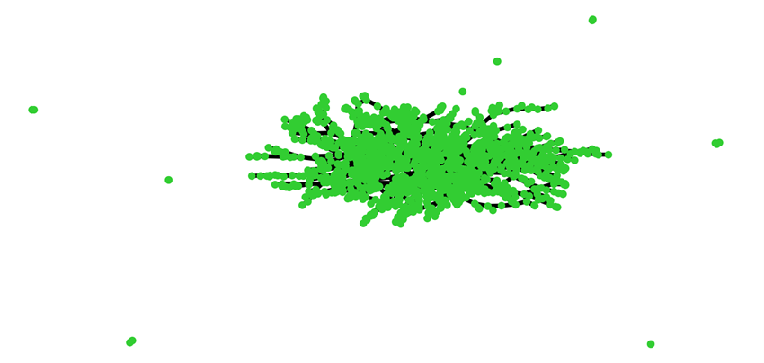

Após a análise destes, decidimos que o k = 2 é o melhor valor de k, porque apesar de já mostrar alguma dispersão ainda é possível perceber algum nível de agregação, o que nos permite perceber as comunidades que existem dentro deste leque de utilizadores. A representação em baixo, representa o clustering com k = 2 com legendas, através da utilização da função clusters.

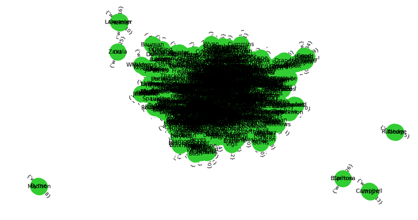

Os fenómenos visualizados acima ocorreram, pois a maior ligação do grafo é "partida" e os clusters tornam-se visíveis quando a aresta a ser "partida" está ligada a um nó e este só tem uma outra ligação a ele conectado.

Caso a aresta a ser retirada só tenha um vértice conectado e esse vértice fique "solto", após a remoção, ele será removido da visualização do grafo, pois foi tomada uma representação mais eficiente, onde não será necessário criar vértices que não estejam ligados a nada.

Com o objetivo de estudarmos as comunidades do nosso ficheiro críamos a função k_clique(graph,k). Esta analisa o grafo, cria um gerador por comunidades que reconhece os vértices que pertencem à mesma comunidade.

```python
def k_cliques(graph,k):
    community=nx.community.k_clique_communities(graph,k) # k=2 porque os grafos dispersos terão sempre 2 vértices;
    # se colocado k maior ou igual a 3, não irá imprimir nada visto que os subgrafos não têm todos 3 vertices
    for i in community:
        print(i)
```

Felizmente depois de várias tentativas e de mudarmos o código inicial (em baixo e que nos permitiu perceber o que era um gerador) conseguimos imprimir os elementos do gerador o que nos permitiu tirar conclusões acerca das comunidades presentes no nosso ficheiro Excel.

```python
def girvan_newman(graph):
    return girvan_newman(graph)
```

Ao utilizar as funções de deteção de comunidade com k = 2 são detetadas 11 comunidades ao utilizar o método k_cliques, que são as ligações únicas entre si fora do "grafo central" e as do próprio "grafo central". Este é um número razoável, visto que a base de dados tem ligações "soltas" e não ligações entre todos os vértices, o que faz com que o número de comunidades seja superior.

Nesta fase do trabalho, sentimos dificuldades em obter o k ≥ 3, ao utilizar o método k_cliques, pois reconhece que é um gerador, porém não é retornado nada na consola quando percorrido o ciclo "for", onde manda imprimir os valores do gerador, ou seja, obriga-nos a utilizar o valor k = 2 como referência para deteção de comunidades. Chegamos à conclusão que para valores de k maiores ou iguais a 3 é necessária a implementação sem o algoritmo de kruskal. O atributo k nesta função corresponde ao número mínimo que cada subgrafo vai ter, daí a conclusão do k = 2, pois nem todos os subgrafos têm mais do que dois vértices e uma aresta/ligação entre eles.

Para ultrapassar esta dificuldade utilizamos o método louvain_communities, implementado tal como se pode ver em baixo, que dá para os valores de k suficientes de clustering, usando sempre o algoritmo de kruskal. Vai calcular os subgrafos pela forma como estão mostrados na figura, ou seja, cada subgrafo representa uma comunidade.

```python
def louvain(graph):
    community=nx.community.louvain_communities(graph)
    for i in community:
        print(i)
```

## Conclusão

O presente trabalho fez-nos desenvolver um projeto onde implementássemos um TAD grafo e aplicássemos os dados num ficheiro de Excel que representa dados do Facebook. Isto de certa forma foi algo desafiador sendo que nos obrigou a descobrir e a tentar implementar algoritmos pouco falados na aula, mas também porque nos obrigou a "pensar fora da caixa", na medida em que tínhamos as definições e o pseudocódigo e tivemos que descobrir uma forma de trabalhar com elas, o que nem sempre se revelou fácil.

Quanto ao que poderíamos ter feito melhor, pensamos que poderíamos ter uma função clustering mais elaborada, uma vez que poderia ter cores, que representassem as diferentes comunidades, por exemplo, sendo que a nossa tem uma implementação mais simples e sucinta, no entanto cumpre o seu objetivo.

Por fim, penso que em trabalhos futuros poderíamos descobrir mais sobre os outros métodos de clustering, realizar e explorar mais as estruturas desenvolvidas e aplicadas neste projeto com outros ficheiros e com temáticas diferentes, com as quais fosse possível explorar os grafos direcionados.

## Referências:

M. T. Goodrich, R. Tamassia and M. H. Goldwasser, “Graph Algorithms”, in Data Structures and Algorithms in Python”, 1st ed .[S.I]: S. Jagannathan & N. Sinenian, 2013, ch. 14, pp. 620-676.

“Representando Grafos em Python | Algoritmos em Python”. https://algoritmosempython.com.br/cursos/algoritmos-python/algoritmos-grafos/representacao-grafos/ (acedido em 19 de maio de 2022).

“Representando Grafos em Python | Algoritmos em Python”. https://algoritmosempython.com.br/cursos/algoritmos-python/algoritmos-grafos/representacao-grafos/ (acedido em 20 de maio de 2022).

A.Barabási, “Networks and Graphs”. BarabásiLab. http://networksciencebook.com/chapter/2#networks-graphs (acedido em 20 de maio de 2022).

H. Bonthu, "Python Tutorial: Working with CSV file for Data Science". Analytics Vidhya. https://www.analyticsvidhya.com/blog/2021/08/python-tutorial-working-with-csv-file-for-data-science/ (acedido em 20 de maio de 2022).

“Creating a graph — NetworkX 1.9 documentation”. Networkx.org. https://networkx.org/documentation/networkx-1.9/tutorial/tutorial.html (acedido em 20 de maio de 2022).

“Graphs in Python - Theory and Implementation”. Stack Abuse. https://stackabuse.com/courses/graphs-in-python-theory-and-implementation/lessons/minimum-spanning-trees-kruskals-algorithm/ (acedido em 23 de maio de 2022).

“What is a Minimum Spanning Tree?”. OpenGenus IQ: Computing Expertise & Legacy. https://iq.opengenus.org/what-is-a-minimum-spanning-tree/ (acedido em 23 de maio de 2022).

“Kruskal's Algorithm – javatpoint”. Javatpoint. https://www.javatpoint.com/kruskal-algorithm (acedido em 23 de maio de 2022).

“Data Structure & Algorithms - Spanning Tree”. Tutorialspoint. https://www.tutorialspoint.com/data_structures_algorithms/spanning_tree.htm (acedido em 24 de maio de 2022).

“Spanning Tree and Minimum Spanning Tree”. Programiz. https://www.programiz.com/dsa/spanning-tree-and-minimum-spanning-tree (acedido em 24 de maio de 2022).

"Kruskal's Algorithm". Programiz. https://www.programiz.com/dsa/kruskal-algorithm (acedido em 25 de maio de 2022).

"Master Kruskal's Algorithm in 5 Steps with Python - Learn Python with Rune". Learn Python with Rune. https://www.learnpythonwithrune.org/master-kruskals-algorithm-in-5-steps-with-python/ (acedido em 25 de maio de 2022).

A. Soularidis, "An Introduction to Kruskal’s Algorithm: Theory and Python Implementation". Python in Plain English. https://python.plainenglish.io/an-introduction-to-kruskals-algorithm-theory-and-python-implementation-6117c164fbc6 (acedido em 25 de maio de 2022).

“Data Structure & Algorithms - Spanning Tree”. Tutorialspoint. https://www.tutorialspoint.com/data_structures_algorithms/spanning_tree.htm (acedido em 25 de maio de 2022).

S. Jain, "Disjoint Set | Union-Find Algorithm - Union by rank and path compression | TutorialHorizon". TutorialHorizon. https://algorithms.tutorialhorizon.com/disjoint-set-union-find-algorithm-union-by-rank-and-path-compression (acedido em 26 de maio de 2022).

“12.6 - Agglomerative Clustering | STAT 508”. PennState: Statistics Online Courses. https://online.stat.psu.edu/stat508/lesson/12/12.6 (acedido em 27 de maio de 2022).

“Hierarchical Clustering with Python and Scikit-Learn”. Stack Abuse. https://stackabuse.com/hierarchical-clustering-with-python-and-scikit-learn/ (acedido em 27 de maio de 2022).

V. Singh, “Hierarchical Clustering in Python”. Blog.quantinsti.com. https://blog.quantinsti.com/hierarchical-clustering-python/ (acedido em 28 de maio de 2022).

“Clustering in Machine Learning – GeeksforGeeks”. GeeksforGeeks. https://www.geeksforgeeks.org/clustering-in-machine-learning/ (acedido em 28 de maio de 2022).

“K-Means Clustering in Python: A Practical Guide – Real Python”. Real Python. https://realpython.com/k-means-clustering-python/ (acedido em 30 de maio de 2022).

A. Carpenter, "Customizing NetworkX Graphs". Towards Data Science. https://towardsdatascience.com/customizing-networkx-graphs-f80b4e69bedf(acedido em 1 de junho de 2022).

Nota: as fotos dos grafos foram realizadas no ASUS ZenBook 14, Core i5, 8th gen. Estas fotos não têm uma cor à volta dos nós, porque apenas decidimos fazer isso, depois de termos o trabalho quase terminado.